# Location analytics: caso práctico

Martín Pons Martínez

## Explicación del caso

La empresa bancaria tiene actualmente 33 sucursales en Londres, una por distrito, y ante la falta de rentabilidad necesita cerrar tres de estas oficinas. Ha decidido que lo hará con aquellas que tengan menor volumen de negocio (suma del consumo de todos los productos) de clientela menor de 55 años (ya que considera que, con sus servicios de banca electrónica, este tipo de clientes estarían cubiertos).

Quiere saber también, para cada uno de los distritos cerrados, si hay alguna oficina u oficinas ubicadas en un distrito cercano a las que pueda derivar a los clientes en caso de necesidad. Para ello, se considerará que las oficinas están geoposicionadas en el centro de los correspondientes distritos.

#### Se pide

- El correspondiente script R generado para su resolución.
- Un documento tipo .doc, con formato similar al del apartado “VIII. Un tutorial de análisis de comportamiento del consumidor mediante R”, que muestre los pasos seguidos para su resolución.

## Configuracion inicial

```r
#librerias
library(tidyverse)
library(rgdal)
library(rgeos)
library(tmap)

# opciones de chunks
knitr::opts_chunk$set(warning=F, message=F)
```

## Carga de datos

Se cargan datos del mapa con los distritos de londres y los datos con información de los clientes. Entre estos datos, se incluye el consumo para cada producto bancario que se ofrece.

```r
# datos mapa londres
i_data_gs <- readOGR(dsn = "data", layer = "london_sport")
# datos de atributos
clientes <- read_csv2("data/LondonCustomer.csv")
```

## PRE-PROCESAMIENTO

### Agrupacion y fusión de datos

En primer lugar hay que agrupar los datos de clientes menores de 55 años, para obtener un monte del total de productos para cada oficina

```r
# obtencion de consumo total de productos por cliente
clientes$NETPRICE_PRO_TOTAL <- apply(select(clientes, matches("NETPRICE")), 1, sum)

# consumo clientes menores de 55 agrupado por oficinas
oficinas_menores_55<- clientes %>%
  filter(AGE < 55) %>%
  group_by(name) %>%
  summarise(consumo = sum(NETPRICE_PRO_TOTAL))
```

Se fusionan ahora estos datos con los datos espaciales cargados. Se emplea la columna names como referencia, ya que los nombres de las oficinas corresponden a los nombres de los distritos.

```r
# fusion de datos del objeto espacial con datos de atributos
i_data_gs@data <- i_data_gs@data %>%
  left_join(oficinas_menores_55, by = "name")
```

### Obtención de distritos/oficinas de menor consumo

Obtenemos los nombres de los tres distritos con menor consumo total para clientes menores de 55 años

```r
# nombres de 3 oficinas con menor consumo
oficinas_menor_consumo <- oficinas_menores_55 %>%
  top_n(-3, consumo) %>%
  .$name

# filtro de datos espaciales para incluir solo los de menor consumo
distritos_cierre_gs <- i_data_gs[is.element(i_data_gs$name,oficinas_menor_consumo),]
```

### Obtención del centroide y areas de influencia para distintas oficinas

Para poder establecer la cercanía de otras oficinas respecto a las oficinas cerradas, hay que situar la situación exacta de las oficinas en el mapa (se asume que es el centroide del distrito) y establecer radios de distancia a partir de esos centros.

```r
# obtencion de situacion de oficinas
oficinas_gs <- gCentroid(i_data_gs, byid = TRUE, id = i_data_gs$name)
oficinas_cierre_gs <- gCentroid(distritos_cierre_gs, byid = TRUE, id = distritos_cierre_gs$name)

# obtencion de objetos espaciales que determinan diferentes grados de cercania radial
i_data_gs_buffer1 <- gBuffer(spgeom = oficinas_cierre_gs, width = 1000)
i_data_gs_buffer2 <- gBuffer(spgeom = oficinas_cierre_gs, width = 2000)
i_data_gs_buffer4 <- gBuffer(spgeom = oficinas_cierre_gs, width = 4000)
i_data_gs_buffer6 <- gBuffer(spgeom = oficinas_cierre_gs, width = 6000)
```

# Resultados y Visualizaciones

En primer lugar se visualizará el consumo para cada distrito, etiquetando los tres distritos de menor consumo

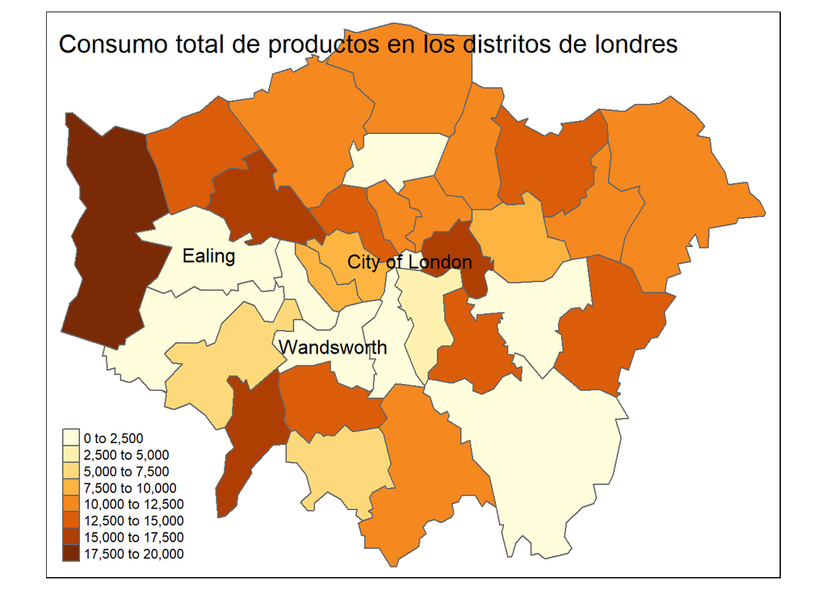

```r
tm_shape(i_data_gs) +
  tm_borders() +
  tm_fill(col = "consumo", style = "fixed",  breaks = seq(0, 20000, by = 2500)) +
  tm_shape(distritos_cierre_gs) +
  tm_text(text = "name") +
  tm_layout(title = "Consumo total de productos en los distritos de londres",
            legend.position = c("left", "bottom"),
            legend.title.color = "white")
```

Las siguientes son las tres oficinas con menor consumo en clientes menores de 55 años, que deberían ser cerradas

```r
oficinas_menor_consumo
```

```
## [1] "City of London" "Ealing"         "Wandsworth"
```

Seguidamente, se visualiza la cercanía de las oficinas más cercanas a las que se deben cerrar, incluyendo varios perímetros de distancia

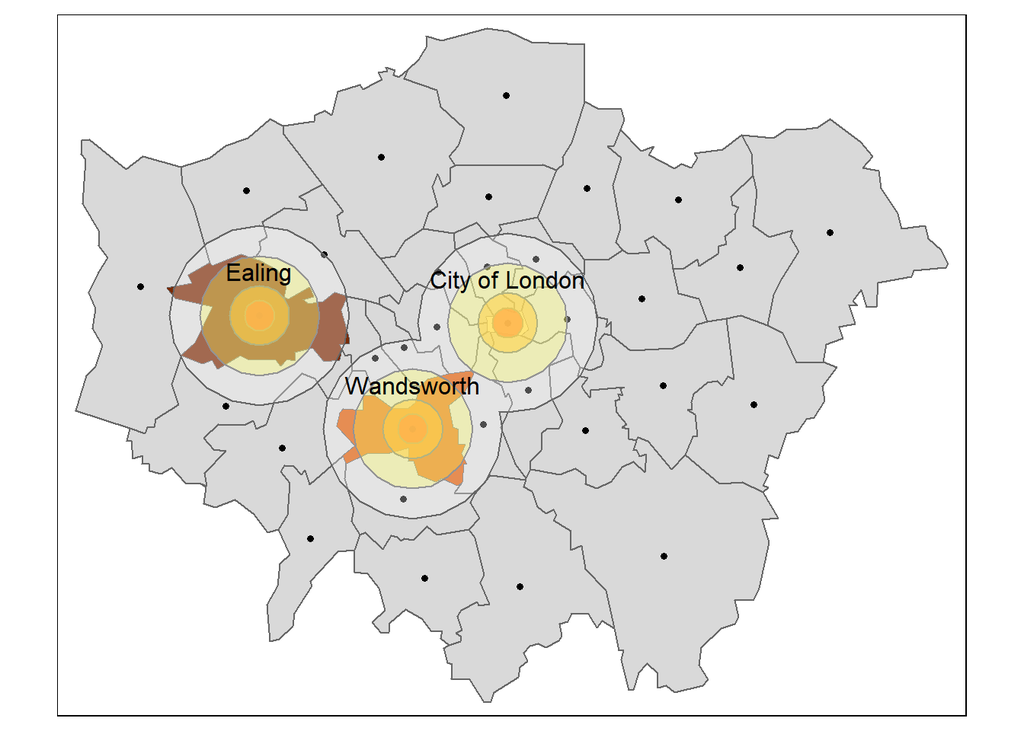

```r
tm_shape(i_data_gs) +
  tm_polygons() +
  tm_shape(distritos_cierre_gs) +
  tm_fill(col = "consumo", legend.show = F) +
  tm_shape(oficinas_gs) +
  tm_dots(size = 0.1) +
  tm_shape(i_data_gs_buffer1) +
  tm_polygons(alpha = 0.8, col = "red") +
  tm_shape(i_data_gs_buffer2) +
  tm_polygons(alpha = 0.6, col = "orange") +
  tm_shape(i_data_gs_buffer4) +
  tm_polygons(alpha = 0.3, col = "yellow") +
  tm_shape(i_data_gs_buffer6) +
  tm_polygons(alpha = 0.3, col = "white") +
  tm_shape(distritos_cierre_gs) +
  tm_text(text = "name", ymod = 1.5, col = "black")
```